# Statistical Modeling & Analysis in `R`

Machine Learning with Boston AirBnB data

Colin Pawlowski

8/28/2018

# Overview

Now that you have seen data wrangling in `R`, which is a necessary first step in any analytics project, we have the building blocks in place to do some more advanced data analytics. In this module, we will build machine learning models using the AirBnB data set. We will cover *regression* models, which can be used to predict continuous variables such as `price`, and *classification* models, which can be used to predict categorical variables such as `amenity_Elevator_in_building`. In the end, you will build your own models and add these to your business analytics dashboard to improve its value.

# Predicting AirBnB Prices

First, let’s load the `tidyverse` package and read in the data set which has been pre-processed for machine learning for us. If you are interested, you can check out the file `airbnbDataPrep.html` to see how this was done.

```r
library(tidyverse)
listings <- readRDS("../data/listingsML.RDS")
```

## 1. Linear Regression

Before we build a linear model to predict price, we’ll reserve a portion of our data to be a test set. There are lots of ways to do this. We’ll use the `caTools` package.

```r
# install.packages("caTools")
library(caTools)
set.seed(123)
spl <- sample.split(listings$price, SplitRatio = 0.7)
listingsTrain <- listings[spl,]
listingsTest <- listings[!spl,]
```

We now have two data frames which contain the training and testing data, respectively. The command `set.seed(123)` ensures that our random splits will be the same, i.e. there is a random number generator in `R` initialized with the value 123. The function `sample.split(y, SplitRatio = 0.7)` generates a random vector of 70% `TRUE`s, 30% `FALSE`s which is the same length as the vector `y`. If `y` has few discrete classes, it preserves the ratio classes in both sets as well.

### (a) Model Training

In `R`, we specify a model structure and then use the corresponding function to tell `R` to optimize for the best-fitting model. For linear regression, the function is `lm()`:

```r
lm1 <- lm(price ~ accommodates, data = listingsTrain)
```

Here, the "~" notation creates a formula object in R. On the left side, we put the dependent variable, and on the right hand side we put the independent variables, separated by "+" signs.

Let’s check out the lm1 object. It is a list of a bunch of relevant information generated by the `lm()` function call, and we can use the `$` to view different elements. The function `summary()` is overloaded for many different objects and often gives a useful snapshot of the model as well.

```r
names(lm1)
```

```
##  [1] "coefficients"  "residuals"     "effects"       "rank"
##  [5] "fitted.values" "assign"        "qr"            "df.residual"
##  [9] "xlevels"       "call"          "terms"         "model"
```

```r
lm1$coefficients
```

```
##  (Intercept) accommodates
##     56.81313     37.60544
```

```r
summary(lm1)
```

```
##
## Call:
## lm(formula = price ~ accommodates, data = listingsTrain)
##
## Residuals:
##     Min      1Q  Median      3Q     Max
## -287.66  -57.02  -19.42   41.34  904.58
##
## Coefficients:
##              Estimate Std. Error t value Pr(>|t|)
## (Intercept)    56.813      3.924   14.48   <2e-16 ***
## accommodates   37.605      1.139   33.02   <2e-16 ***
## ---
## Signif. codes:  0 '***' 0.001 '**' 0.01 '*' 0.05 '.' 0.1 ' ' 1
##
## Residual standard error: 95.62 on 2499 degrees of freedom
## Multiple R-squared:  0.3037, Adjusted R-squared:  0.3035
## F-statistic:  1090 on 1 and 2499 DF,  p-value: < 2.2e-16
```

### (b) Model Visualization

As another check on inference quality, let’s plot the fitted line. There are some nifty functions in the `modelr` package that make interacting with models easy in the `tidyr` and `dplyr` setting. We’ll use `modelr::add_predictions()` here.

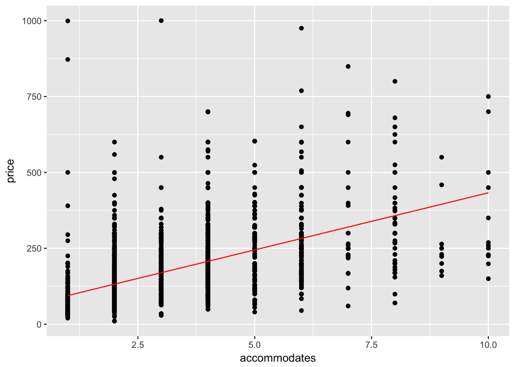

```r
# install.packages("modelr")
library(modelr)
listingsTrain %>%
  add_predictions(lm1) %>%
  ggplot(aes(x = accommodates)) +
  geom_point(aes(y = price)) +
  geom_line(aes(y = pred), color = 'red')
```

Nice. We can also remove the linear trend and check the residual uncertainty, which we’ll do here using `modelr::add_residuals()`. This is helpful to make sure that the residual uncertainty looks like random noise rather than an unidentified trend.

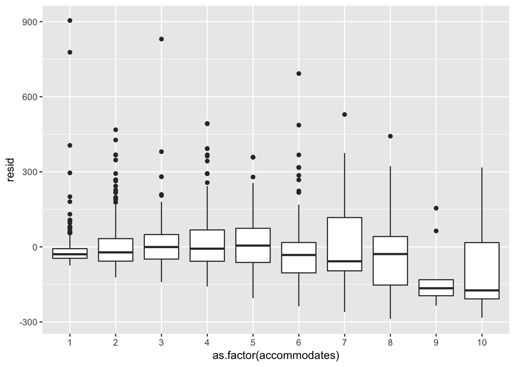

```r
listingsTrain %>%
  add_residuals(lm1, var = "resid") %>%
  group_by(as.factor(accommodates)) %>%
  ggplot(aes(x = as.factor(accommodates), y = resid)) +
  geom_boxplot()
```

Things are pretty centered around zero, with the exception of 9+ person accommodations. Maybe the model doesn’t apply so well here, why might that be?

### (c) Model Evaluation

Now, what if we wanted to *quantify* how well the model predicts these out-of-sample values? We’ll look at the out-of-sample R^2 (OSR^2), also known as the "coefficient of determination":

OSR^2 = 1 - SSE / SST,

where:

- SSE = $\sum_{i=1}^n (\hat{y}_i - y_i)^2$ ("Sum of Squares Error")
- SST = $\sum_{i=1}^n (\bar{y} - y_i)^2$ ("Sum of Squares Total")

In these equations, $\hat{y}_i$ is the predicted value for test observation $i$, $y_i$ is the actual value, $n$ is the size of the test set, and $\bar{y}$ is the mean of $y_i$ in the training set. Let’s code this up.

```r
pred_test <- predict(lm1, newdata = listingsTest)
OSR2 <- 1 - sum((pred_test - listingsTest$price) ^ 2) /
  sum((mean(listingsTrain$price) - listingsTest$price) ^ 2)
```

The in-sample R^2 value is equal to the "Multiple R-squared" value returned by summary(). Are we overfitting?

```r
summary(lm1)
```

```
##
## Call:
## lm(formula = price ~ accommodates, data = listingsTrain)
##
## Residuals:
##     Min      1Q  Median      3Q     Max
## -287.66  -57.02  -19.42   41.34  904.58
##
## Coefficients:
##              Estimate Std. Error t value Pr(>|t|)
## (Intercept)    56.813      3.924   14.48   <2e-16 ***
## accommodates   37.605      1.139   33.02   <2e-16 ***
## ---
## Signif. codes:  0 '***' 0.001 '**' 0.01 '*' 0.05 '.' 0.1 ' ' 1
##
## Residual standard error: 95.62 on 2499 degrees of freedom
## Multiple R-squared:  0.3037, Adjusted R-squared:  0.3035
## F-statistic:  1090 on 1 and 2499 DF,  p-value: < 2.2e-16
```

```r
OSR2
```

```
## [1] 0.3503554
```

### (d) First Set of Exercises

**1. Building a simple model**

Regress price on review_scores_rating. Plot the regression line and the actual training points, and find the in-sample R^2. (Read below for more details if you need them.)

**DETAILS:**

- Use `lm()` to learn the linear relationship
- In-sample R^2 is one of the outputs of `summary()`
- Use `add_predictions()` and ggplot tools for the plotting

**2. Adding more variables**

Try to beat the out-of-sample performance of the price ~ accommodates model by adding other variables. You can use `names(listings)` to explore potential predictors. If you start getting errors or unexpected behavior, make sure the predictors are in the format you think they are. You can check this using the `summary()` and `str()` functions on listings$<variable of interest>.

**3. Median Regression**

Since we’re dealing with data on price, we expect that there will be high outliers. While least-squares regression is reliable in many settings, it has the property that the estimates it generates depend quite a bit on the outliers. One alternative, median regression, minimizes *absolute* error rather than squared error. This has the effect of regressing on the median rather than the mean, and is more robust to outliers. In `R`, it can be implemented using the `quantreg` package.

For this exercise, install the quantreg package, and compare the behavior of the median regression fit (using the `rq()`) function) to the least squares fit from `lm()` on the original listings data set given below which includes all the price outliers.

```r
data <- readRDS("../data/listingsMLwithOutliers.RDS")
```

*Hint:* Enter ?rq for info on the rq function.

**DETAILS:**

- Split into training/testing set
- Fit the median and linear regression models
- Plot the two lines together using `gather_predictions`, which is very similar to the `add_predictions` function that we saw in class.
- Add “color = model” as a geom_line aesthetic to differentiate the two models in the plot.

### (e) Summary and More about Formulas

First, let’s review the pattern, because it can be generalized to a whole bunch of more complex models. We asked the questions: How does listing price depend on the number of people it accommodates? How well does accommodation size predict price? Since we were interested in prediction, we reserved part of our data as a test set. We then chose to use a linear model to answer these questions, and found the corresponding function `lm()`. This function, and modelling functions in general, takes as arguments:

- Data on the response and predictor variables, usually through a `formula` object
- Model parameters (in the case of `lm()`, we used all the default values)

`R` then automatically found the “best” linear model by computing the least squares estimate, and returned a `lm` object, which was a list including information about:

- Fitted coefficients
- Residuals
- Statistical significance
- And more…

We interacted with the model to evaluate goodness-of-fit and out-of-sample performance. In our case, we used the `caTools` and `dplyr` framework to do this cleanly.

We didn’t say too much about the `price ~ accommodates` syntax. Many modelling functions in `R` take `formula`s as arguments, together with a `data` argument. The `data` argument specifies the data frame, and the `formula` argument tells the model which are the responses and which are the predictors. We’ll play around with formulas in the exercises, but here are a few helpful pointers:

- The `~` separates the response (on the left) from the predictors (on the right)
- Predictors are separated with a `+`
- Use `.` on the right-hand side to include all predictors in a given data frame
- You can also use `.-x` to include all predictors except `x`
- To include interactions between variables, use the `*` symbol. For example: `y ~ x + z + x*z` expresses the form: “regress `y` on `x`, `z`, and on `x` interacted with `z`
- To exclude the intercept term, include `-1` or `+0` on the right-hand side For more detailed info, see https://stat.ethz.ch/R-manual/R-devel/library/stats/html/formula.html.

### (f) Adding More Features

Let’s work a bit harder on predicting price, this time using more than one predictor. In fact, we’ll add a bunch of predictors to the model and see what happens. We can do this using the `.` notation in our formula:

```r
lm2 <- lm(price ~ ., data = listingsTrain)
```

```r
pred_test <- predict(lm2, newdata = listingsTest)
OSR2_2 <- 1 - sum((pred_test - listingsTest$price) ^ 2) /
  sum((mean(listingsTrain$price) - listingsTest$price) ^ 2)
```

The in-sample R^2 value is equal to the "Multiple R-squared" value returned by summary(). Are we overfitting?

```r
summary(lm2)$r.squared
```

```
## [1] 0.6253439
```

```r
OSR2_2
```

```
## [1] -13297.75
```

This has better in-sample performance than our initial model, but we have a serious overfitting problem here, meaning that the training error is smaller than the test error. The model is too powerful for the amount of data we have. Sometimes, `R` recognizes this by giving warnings about a "rank-deficient fit."

## 2. Regularized Linear Regression

But is there still a way to use the info from all these variables without overfitting? Yes! One way to do this is by regularized, or penalized, regression.

Mathematically, we add a term to the optimization problem that we’re solving when fitting a model, a term which penalizes models that get too fancy without enough data. If we call $\beta$ the coefficient vector that we’d like to learn about for linear regression, then the regular regression we’ve worked with looks like
$$\min_\beta \sum_{i=1}^n (y_i-x_i^T\beta)^2,$$
but penalized regression looks like
$$\min_\beta \sum_{i=1}^n (y_i-x_i^T\beta)^2 + \lambda ||\beta||.$$

There are two types of flexibility within this framework:

- Choice of norm, a structural decision, and
- Choice of $\lambda$, a parametric decision.

Two natural choices of norm are the Euclidean 1- and 2-norms. When we use the 2-norm, it’s often called “ridge regression.” We’ll focus today on the 1-norm, or “LASSO regression”. On a very simple level, both types of regression shrink all the elements of the unconstrained $\beta$ vector towards zero, some more than others in a special way. LASSO shrinks the coefficients so that some are equal to zero. This feature is nice because it helps us interpret the model by getting rid of the effects of many of the variables.

To do LASSO, we’ll use the `glmnet` package. Of note, this package doesn’t work very elegantly with the `tidyverse` since it uses matrix representations of the data rather than data frame representations. However, it does what it does quite well, and will give us a chance to see some base R code. Let’s load the package and check out the function `glmnet()`. We can see the documentation from the command line using `?glmnet`.

```r
library(glmnet)
?glmnet
```

Notice that `glmnet()` doesn’t communicate with the data via formulas. Instead, it wants a matrix of predictor variables and a vector of values for the variable we’re trying to predict, including all the categorical variables that `R` automatically expanded into indicator variables. Fortunately, `R` has a `model.matrix()` function which takes a data frame and gets it into the right form for `glmnet()` and other functions with this type of input.

First, we need to convert the data to a matrix for X and a vector for Y:

```r
x <- model.matrix(price ~ ., data = listings)
y <- as.vector(listings$price)
```

Next, split into training/testing sets:

```r
set.seed(123)
spl <- sample.split(y, SplitRatio = 0.7)
xTrain <- x[spl, ]
xTest <- x[!spl, ]
yTrain <- y[spl]
yTest <- y[!spl]
```

### (a) Model Training

Finally, let’s fit a our first LASSO model. There’s a way to specify lambda manually, but let’s just accept the default for now and see what we get.

```r
lasso1 <- glmnet(xTrain, yTrain)
```

This time the `summary()` function isn’t quite as useful:

```r
summary(lasso1)
```

```
##           Length Class     Mode
## a0           90  -none-    numeric
## beta      12150  dgCMatrix S4
## df           90  -none-    numeric
## dim           2  -none-    numeric
## lambda       90  -none-    numeric
## dev.ratio    90  -none-    numeric
## nulldev       1  -none-    numeric
## npasses       1  -none-    numeric
## jerr          1  -none-    numeric
## offset        1  -none-    logical
## call          3  -none-    call
## nobs          1  -none-    numeric
```

It does give us some info, though. Notice that “lambda” is a vector of length 90. The `glmnet()` function has defined 90 different values of lambda and found the corresponding optimal beta vector for each one! We have 90 different models here. Let’s look at some of the coefficients for the different models. We’ll start with one where lambda is really high:

```r
lasso1$lambda[1]
```

```
## [1] 63.13239
```

```r
lasso1$beta[, 1] # How many coefficients are nonzero?
```

```
##                                   (Intercept)
##                                             0
##                                    host_since
##                                             0
##                     host_response_timeUNKNOWN
##                                             0
##                host_response_timewithin a day
##                                             0
##          host_response_timewithin a few hours
##                                             0
##              host_response_timewithin an hour
##                                             0
##                            host_response_rate
##                                             0
##                          host_acceptance_rate
##                                             0
##                            host_is_superhostt
##                                             0
##                           host_listings_count
##                                             0
##                     host_total_listings_count
##                                             0
##                     host_has_profile_picOther
##                                             0
##                       host_identity_verifiedt
##                                             0
##                neighbourhood_cleansedBack Bay
##                                             0
##             neighbourhood_cleansedBeacon Hill
##                                             0
##                neighbourhood_cleansedBrighton
##                                             0
##             neighbourhood_cleansedCharlestown
##                                             0
##               neighbourhood_cleansedChinatown
##                                             0
##              neighbourhood_cleansedDorchester
##                                             0
##                neighbourhood_cleansedDowntown
##                                             0
```

[output cut: 215 more lines]

```
##                                             0
##                                host_jumioTRUE
##                                             0
##                                  host_kbaTRUE
##                                             0
##                        host_manual_onlineTRUE
##                                             0
##                       host_manual_offlineTRUE
##                                             0
##                               host_googleTRUE
##                                             0
##                              host_sent_idTRUE
##                                             0
##                                host_weiboTRUE
##                                             0
```

Here the penalty on the size of the coefficients is so high that `R` sets them all to zero. Moving to some smaller lambdas:

```r
lasso1$lambda[10]
```

```
## [1] 27.3285
```

```r
beta <- lasso1$beta[, 10]
beta[which(beta != 0)]
```

```
## room_typePrivate room          accommodates              bedrooms
##             -42.72412              11.63955              10.78565
```

```r
lasso1$lambda[20]
```

```
## [1] 10.77892
```

```r
beta <- lasso1$beta[, 20]
beta[which(beta != 0)]
```

```
##    neighbourhood_cleansedBack Bay                          latitude
##                        15.5584281                       305.7700299
##                         longitude             room_typePrivate room
##                        34.9519215                       -55.2180078
##              room_typeShared room                      accommodates
##                        -5.7635651                        10.8379687
##                         bathrooms                          bedrooms
##                        12.6340094                        26.4403970
##                   availability_30            review_scores_location
##                         0.2280881                         2.1190305
## require_guest_phone_verificationt                 reviews_per_month
##                        14.3962003                        -0.3104790
##                    amenity_TVTRUE      amenity_Air_ConditioningTRUE
##                         8.9746045                        10.0987889
##              amenity_Cable_TVTRUE  amenity_Elevator_in_BuildingTRUE
##                         5.3811867                         9.0415321
```

### (b) Cross-Validation

How do we choose which of the 90 models to use? Or in other words, how do we “tune” the $\lambda$ parameter? We’ll use a similar idea to the training-test set split called cross-validation.

The idea behind cross-validation is this: what if we trained our family of models (in this case 90) on only some of the training data and left out some other data points? Then we could use those other data points to figure out which of the lambdas works best out-of-sample. So we’d have a training set for training all the models, a validation set for choosing the best one, and a test set to evaluate performance once we’ve settled on a model.

There’s just one other trick: since taking more samples reduces noise, could we somehow take more validation set samples? Here’s where *cross*-validation comes in. We divide the training data into groups called *folds*, and for each fold repeat the train-validate procedure on the remaining training data and use the current fold as a validation set. We then average the performance of each model on each fold and pick the best one.

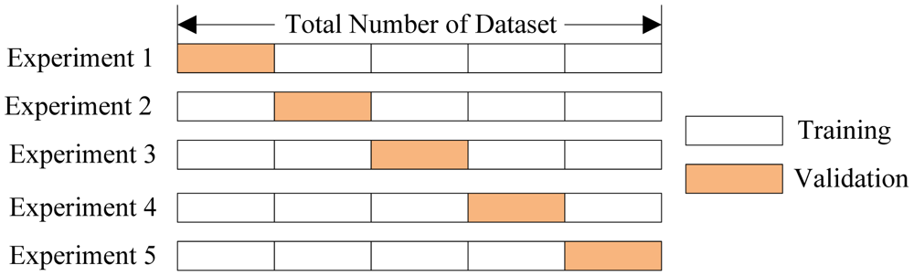

This is a very common *resampling* method that applies in lots and lots of settings. Lucky for us the glmnet package has a very handy function called `cv.glmnet()` which does the entire process automatically. Let’s look at the function arguments using `?cv.glmnet`.

The relevant arguments for us right now are

- x, the matrix of predictors
- y, the response variable
- nfolds, the number of ways to split the training set (defaults to 10)
- type.measure, the metric of prediction quality. It defaults to mean squared error, the square of RMSE, for linear regression.

Let’s do the cross-validation. Because the cross-validation procedure is inherently randomized, let’s set the seed beforehand to obtain consistent results.

```r
set.seed(123)
lasso2 <- cv.glmnet(xTrain, yTrain)
summary(lasso2) # What does the model object look like?
```

```
##            Length Class  Mode
## lambda     80     -none- numeric
## cvm        80     -none- numeric
## cvsd       80     -none- numeric
## cvup       80     -none- numeric
## cvlo       80     -none- numeric
## nzero      80     -none- numeric
## name        1     -none- character
## glmnet.fit 12     elnet  list
## lambda.min  1     -none- numeric
## lambda.1se  1     -none- numeric
```

Notice the "lambda.min". This is the best lambda as determined by the cross validation. "lambda.1s" is the largest lambda such that the "error is within 1 standard error of the minimum."

There’s another automatic plotting function for `cv.glmnet()` which shows the error for each model:

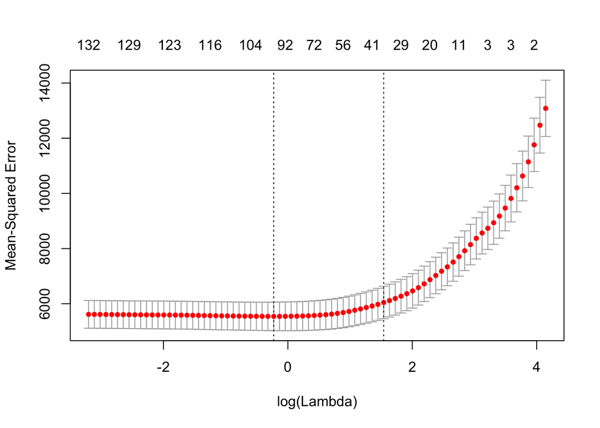

```r
plot.cv.glmnet(lasso2)
```

The first vertical dotted line shows `lambda.min`, and the second is `lambda.1se`. The figure illustrates that we cross-validate to find the “sweet spot” where there’s not too much bias (high lambda) and not too much noise (low lambda). The left-hand side of this graph is flatter than we’d sometimes see, meaning that the unpenalized model may not be too bad. However, increasing lambda increases interpretability at close to no loss in prediction accuracy!

### (c) Model Evaluation

Let’s again compare training and test error. Because we are using glmnet we need to use the specialized `predict.cv.glmnet()` function to get the in-sample and out-of-sample predictions:

```r
?predict.cv.glmnet
pred_train <- predict.cv.glmnet(lasso2, newx = xTrain, s = "lambda.1se")
pred_test <- predict.cv.glmnet(lasso2, newx = xTest, s = "lambda.1se")
```

Then use the formula to compute R^2 and OSR^2:

```r
R2_lasso <- 1 - sum((pred_train - yTrain) ^ 2) /
  sum((mean(yTrain) - yTrain) ^ 2)
OSR2_lasso <- 1 - sum((pred_test - yTest) ^ 2) /
  sum((mean(yTrain) - yTest) ^ 2)
R2_lasso
```

```
## [1] 0.5563813
```

```r
OSR2_lasso
```

```
## [1] 0.5726666
```

Has the overfitting issue improved? Let’s check out the coefficients in our final model:

```r
lambdaIndex <- which(lasso2$lambda == lasso2$lambda.1se)
beta <- lasso2$glmnet.fit$beta[,lambdaIndex]
beta[which(beta != 0)]
```

```
##                host_response_timewithin a day
##                                  -2.033463443
##                neighbourhood_cleansedBack Bay
##                                  31.639324877
##             neighbourhood_cleansedBeacon Hill
##                                  17.353613387
##              neighbourhood_cleansedDorchester
##                                 -19.192004807
##                neighbourhood_cleansedDowntown
##                                   9.133209220
##             neighbourhood_cleansedEast Boston
##                                 -33.364985575
##                  neighbourhood_cleansedFenway
##                                   3.232927204
## neighbourhood_cleansedSouth Boston Waterfront
##                                   1.701234231
##               neighbourhood_cleansedSouth End
##                                   7.005775993
##                neighbourhood_cleansedWest End
##                                  -1.789129831
##                                      latitude
##                                 366.457205590
##                                     longitude
##                                 270.399307885
##                         room_typePrivate room
##                                 -54.657594113
##                          room_typeShared room
##                                 -44.340280632
##                                  accommodates
##                                   7.748084609
##                                     bathrooms
##                                  17.704097298
##                                      bedrooms
##                                  32.464213030
##                                          beds
##                                   4.824956027
##                               availability_30
##                                   0.355803287
##                               availability_60
##                                   0.183023936
```

[output cut: 23 more lines]

```
##                                  13.037673565
##                          amenity_Cable_TVTRUE
##                                   2.908146420
##                  amenity_Indoor_FireplaceTRUE
##                                  12.563567026
##          amenity_Buzzer_Wireless_IntercomTRUE
##                                   3.201217948
##              amenity_Elevator_in_BuildingTRUE
##                                   8.854994227
##                           amenity_DoormanTRUE
##                                   1.632538156
##                             host_facebookTRUE
##                                  -2.474849384
##                              host_reviewsTRUE
##                                  -0.225823567
```

```r
lasso2$lambda.1se
```

```
## [1] 4.665939
```

One more note on cross-validation: the `glmnet` package has built-in functionality for cross-validation. In situations where that’s not the case, `modelr::crossv_kfold()` will prepare data for cross-validation in a nice way.

### (d) Second Set of Exercises

**1. Elastic-Net Regression**

The glmnet package is actually more versatile than just LASSO regression. It also does ridge regression (with the l2 norm), and any mixture of LASSO and ridge (also known as elastic-net). The mixture is controlled by the parameter alpha: alpha=1 is the default and corresponds to LASSO, alpha=0 is ridge, and values in between are mixtures between the two (check out the formula using ?glmnet). One could use cross validation to choose this parameter as well. For now, try just a few different values of alpha on the model we built for LASSO using `cv.glmnet()` (which does not cross-validate for alpha automatically). How do the new models do on out-of-sample R^2?

# Predicting AirBnB Elevator Access

So far, we have looked at models for predicting price, which is a continuous variable. For this type of task, we use *regression* methods. However, if we want to predict a variable which is categorical, we must use *classification* methods. Let’s take a look at using one such method, **Logistic Regression**, to predict the binary variable whether or not the AirBnB includes an elevator.

## 1. Logistic Regression

Logistic regression is part of the class of generalized linear models (GLMs), which build directly on top of linear regression. These models take the linear fit and map it through a non-linear function. For logistic regression this function is the logistic function,

$$f(x) = \frac{e^x}{1+e^x},$$

which looks like this:

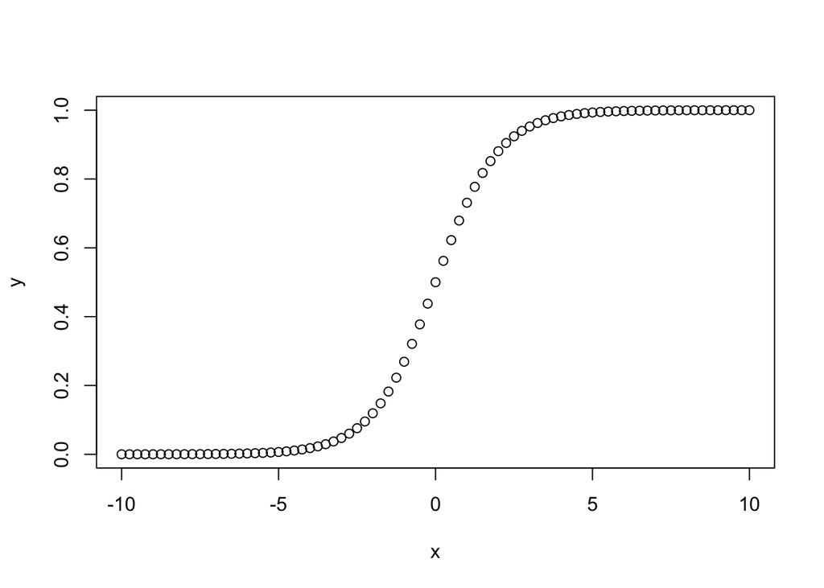

```r
x <- seq(-10, 10, 0.25)
y <- exp(x) / (1 + exp(x))
plot(x, y)
```

Since the function stays between zero and one, it can be interpreted as a mapping from predictor values to a probability of being in one of two classes.

Let’s apply this model to the `listings` data. Let’s try to predict which listings have elevators in the building by price. First, we need to split the data into training and testing sets.

```r
set.seed(123)
spl <- sample.split(listings$amenity_Elevator_in_Building, SplitRatio = 0.7)
elevatorTrain <- listings[spl,]
elevatorTest <- listings[!spl,]
```

One nice thing about using `sample.split` for classification is that it preserves the ratio of class labels in the training and testing sets.

### (a) Model Training

Instead of the `lm()` function, we’ll now use `glm()`, but the syntax is almost exactly the same:

```r
logReg1 <- glm(amenity_Elevator_in_Building ~ price,
            family = "binomial", data = elevatorTrain)
summary(logReg1)
```

```
##
## Call:
## glm(formula = amenity_Elevator_in_Building ~ price, family = "binomial",
##     data = elevatorTrain)
##
## Deviance Residuals:
##     Min       1Q   Median       3Q      Max
## -2.5782  -0.7236  -0.5971  -0.5150   2.0449
##
## Coefficients:
##               Estimate Std. Error z value Pr(>|z|)
## (Intercept) -2.1211919  0.0959801  -22.10   <2e-16 ***
## price        0.0054134  0.0004379   12.36   <2e-16 ***
## ---
## Signif. codes:  0 '***' 0.001 '**' 0.01 '*' 0.05 '.' 0.1 ' ' 1
##
## (Dispersion parameter for binomial family taken to be 1)
##
##     Null deviance: 2760.7  on 2492  degrees of freedom
## Residual deviance: 2587.3  on 2491  degrees of freedom
## AIC: 2591.3
##
## Number of Fisher Scoring iterations: 4
```

### (b) Model Accuracy

Let’s explore out-of-sample performance. To evaluate the prediction accuracy of our logistic regression model, we count up the number of times each of the following occurs:

- Y = 1, prediction = 1 (True Positive)
- Y = 0, prediction = 1 (False Positive)
- Y = 1, prediction = 0 (False Negative)
- Y = 0, prediction = 0 (True Negative)

A table that holds these values is called a “confusion matrix”. Then,

accuracy = (# True Positives + # True Negatives) / (Total # of observations)

Let’s construct the confusion matrix and calculate the training and testing accuracy for our model:

```r
# Training Confusion Matrix
pred_train <- predict(logReg1, newdata = elevatorTrain)
confusionMatrixTrain <- table(elevatorTrain$amenity_Elevator_in_Building,
                         ifelse(pred_train > 0.5, "pred = 1", "pred = 0"))
confusionMatrixTrain
```

```
##
##         pred = 0 pred = 1
##   FALSE     1849       40
##   TRUE       588       16
```

```r
# Training Accuracy
sum(diag(confusionMatrixTrain)) / nrow(elevatorTrain)
```

```
## [1] 0.7480947
```

```r
# Testing Confusion Matrix
pred_test <- predict(logReg1, newdata = elevatorTest)
confusionMatrixTest <- table(elevatorTest$amenity_Elevator_in_Building,
                         ifelse(pred_test > 0.5, "pred = 1", "pred = 0"))
confusionMatrixTest
```

```
##
##         pred = 0 pred = 1
##   FALSE      792       17
##   TRUE       254        5
```

```r
# Testing Accuracy
sum(diag(confusionMatrixTest)) / nrow(elevatorTest)
```

```
## [1] 0.7462547
```

Are we overfitting with this model?

### (c) Model AUC

Ultimately, we want to predict whether or not a listing has an elevator. However, logistic regression gives us something a bit different: a probability that each listing has an elevator. This gives us flexibility in the way we predict. The most natural thing would be to predict that any listing with predicted probability above 0.5 *has* an elevator, and any listing with predicted probability below 0.5 *does not have* an elevator. But what if I use a wheelchair and I want to be really confident that there’s going to be an elevator? I may want to use a cutoff value of 0.9 rather than 0.5. In fact, we could choose any cutoff value and have a corresponding prediction model. How should tuning this value affect the False Postive and False Negative rates?

There’s a really nice metric that measures the quality of all cutoffs simultaneously: *AUC*, for “Area Under the receiver operating characteristic Curve.” That’s a mouthful, but the idea is simpler: For every cutoff, we’ll plot the *false positive rate* against the *true positive rate* and then take the area under this curve. (A *positive* in our case is a listing that has an elevator. So a *true positive* is a listing that we predict has an elevator and really does have an elevator, while a *false positive* is a listing that we predict has an elevator and does *not* actually have an elevator.)

As the cutoff shrinks down from 1 to 0, the rate of total positives will increase. If the rate of true positives increases faster than the rate of false positives, this is one indication that the model is good. This is what AUC measures.

The `ROCR` package is one implementation that allows us to plot ROC curves and calculate AUC. Here’s an example:

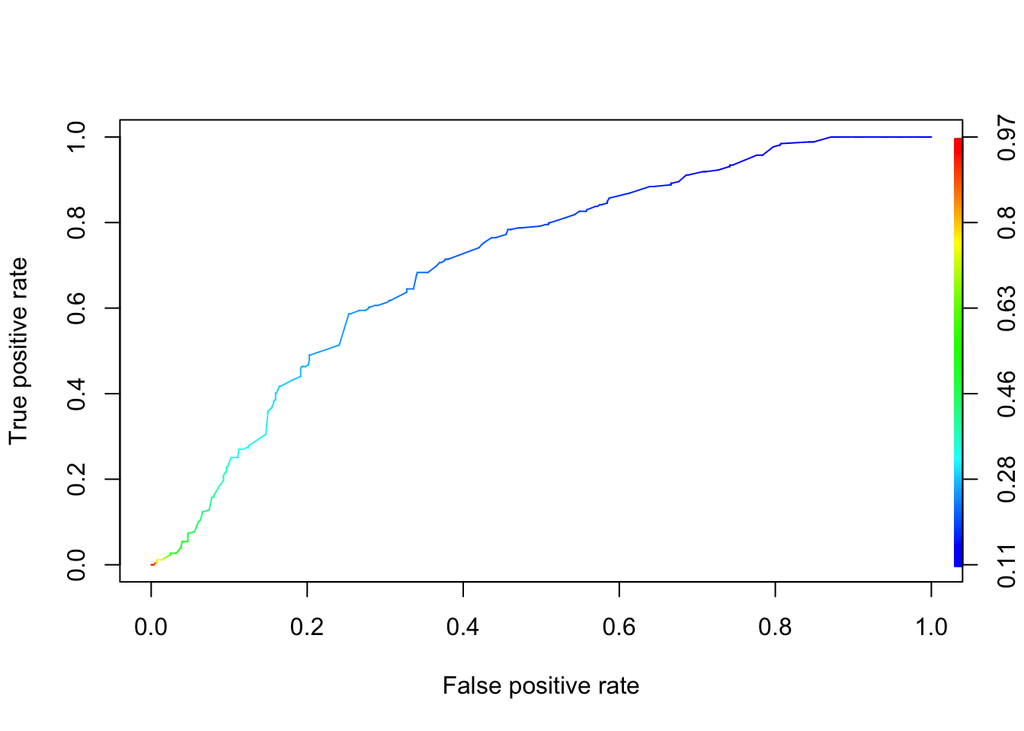

```r
# install.packages("ROCR")
library(ROCR)
pred_test <- predict(logReg1, newdata = elevatorTest, type = "response")
pred_obj <- prediction(pred_test, elevatorTest$amenity_Elevator_in_Building)

# Creating a prediction object for ROCR
perf <- performance(pred_obj, 'tpr', 'fpr')
plot(perf, colorize = T) # ROC curve
```

```r
performance(pred_obj, 'auc')@y.values[[1]] # AUC - a scalar measure of performance
```

```
## [1] 0.7075397
```

As you can see, the `performance()` function in the `ROCR` package is versatile and allows you to calculate and plot a bunch of different performance metrics.

In our case, this model gives an AUC of 0.7. The worst possible is 0.5 - random guessing. We’re definitely better than random here, and could likely improve by adding more predictors.

We’ve covered basic logistic regression, but just as with linear regression there are many, many extensions. For example, we could do regularized logistic regression if we wanted to use many predictors, using the `glmnet` package.

### (d) Third Set of Exercises

**1. Add more variables to Logistic Regression**

Try to beat the out-of-sample performance for logistic regression of elevators on price by adding new variables. Compute the out-of-sample AUC of the final model, and plot the ROC curve.

# Adding Predictive Models to the Business Dashboard

Now that you have been introduced to statistical modelling in `R`, it’s time to take these tools and use them to build your own predictive model as a module for the dashboard. In the process, you may consider the following questions:

- What is the outcome variable that you would like to predict? What are the independent variables?
- Who is the target audience for your predictive model? (This could be AirBnB, landlords, renters, etc.)
- What are some key questions that your target audience might have? How does your predictive model provide insight to address these questions?
- How could your target audience use the output of your model to change their behavior to improve some objective?
- How could you improve or change this predictive model? If you could add more data, what would it be?

For this part, you will work in the same teams as before. If there is time remaining at the end of the session, we will have groups present their dashboards for short 1 minute presentations.